# Definition of the data to be used: empirical vs theoretical forward prices

## Python and data imports

```python
import pandas as pd
import numpy as np
import seaborn as sns
import matplotlib.pyplot as plt
```

```python
data = pd.read_csv('dataset.csv', index_col=0, parse_dates=True)
```

```python
%matplotlib inline
```

```python
data.columns
```

```
Index(['S&P 500', 'EuroStoxx 50', 'Nikkei 225', 'SMI', 'FTSE 100',
       'USD 1M Libor', 'EUR 1M Libor', 'JPY 1M Libor', 'CHF 1M Libor',
       'GBP 1M Libor', 'EURUSD', 'USDJPY', 'USDCHF', 'GBPUSD', 'EUR1MV=',
       'JPY1MV=', 'CHF1MV=', 'GBP1MV='],
      dtype='object')
```

# Forward versus Spot:

First of all, we are going to clarify some naming conventions in the currency market, for the seek of clarity. Many times, the naming convention is to use concepts as domestic vs foreign currencies. However, this concepts can be confusing in relation with the naming conventions of different exchange rates, since the numeraire is not consistently our foreign or domestic currency.

In order to avoid confusion, from now on, given the name of an exchange rate as EURUSD, for example, we will use the term currency 1 (or C1) to the asset currency of the cross (the first being named), while we will use the term currency 2 (or C2) for the numeraire currency of the exchange rate (the second one being named).

This way, the crosses are named as C1C2 and for example in EURUSD we would have C1=EUR and C2=USD, and EURUSD spot rate will designate the USD denominated price of 1 Euro.

In the industry, the difference in price points between the spot and the forward price is usually called "swap points". [Foreign swap reference](https://en.wikipedia.org/wiki/Foreign_exchange_swap)

The theoretical price of a forward contract in the FX market is very simple and is based in the Uncovered Interest Rate Parity. [Interest rate parity](https://en.wikipedia.org/wiki/Interest_rate_parity)

So at a given point of time t, the price of a forward with maturity = m days is:

$ F_m(t) = S(t) \frac{(1 + r_{C2}(t))^{\frac{m}{360}}}{(1 + r_{C1}(t))^{\frac{m}{360}}} $

Where $S(t)$ is the spot rate at time time, $r_{C1}(t)$ is the reference interest rate for currency C1 at time t, and $r_{C2}(t)$ is the currency C2 reference interest rate. Please note that compound interest is assumed rather than simple.

Given this, the swap points with tenor m at any given point of time are defined as:

$SP_m(t) = F_m(t) - S(t) = S(t) \left( \frac{(1 + r_{C2}(t))^{\frac{m}{360}}}{(1 + r_{C1}(t))^{\frac{m}{360}}} - 1 \right) $

So now we are able to compare the **empirical** swap points (e.g. simply 'JPY1MV=' - 'USDJPY') versus the **theoretical** ones (computed using the spot and the LIBOR rates of the dataset).

## Empirical swap points

The empirical swap points are just the difference between the forward and the spot forwards from our database.

```python
fwds = ['JPY1MV=', 'CHF1MV=', 'GBP1MV=', 'EUR1MV=']
curren = ['USDJPY', 'USDCHF', 'GBPUSD', 'EURUSD']
```

```python
idx = data[fwds+curren].dropna().index
```

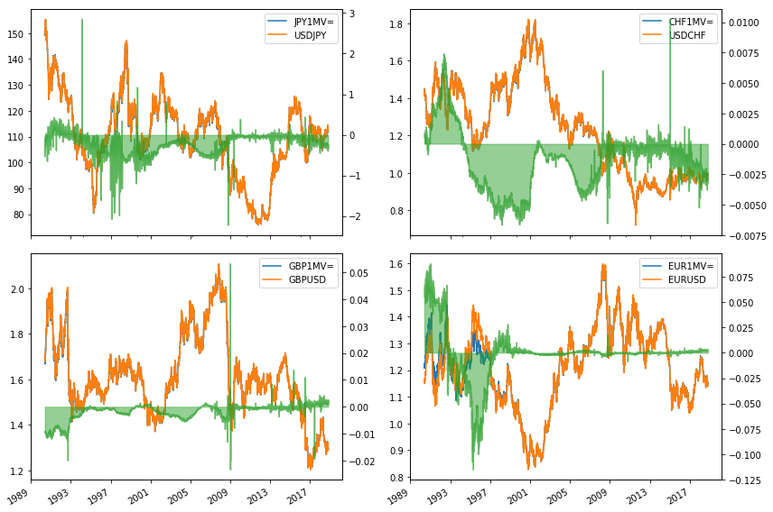

```python
difs = pd.DataFrame()
fig, ax = plt.subplots(2, 2, figsize=(12, 8))
ax = ax.ravel()
for i in range(len(fwds)):
    data[[fwds[i]]+[curren[i]]].loc[idx].plot(ax = ax[i])
    difs[curren[i]] = (data[fwds[i]] - data[curren[i]]).loc[idx]
    difs[curren[i]].plot.area(stacked=False, ax=ax[i], secondary_y=True)
plt.tight_layout()
```

In the graphs, we can find the swap points in green. As we can see, there are some non-smooth values at some points in time. These discontinuities in the cost of hedging might be cause by several factors:

1. Differences in the sampling time between forward and spot rates, evidenced more clearly during stressed market situations where the spot prices had varied very quickly.
2. Deviations from the theoretical price due to the inability of arbitrageurs to profit from these differences under low-liquidity market situations (i.e. during stressed markets). Please note that rather than a non-arbitrage price the forward mid prices should be in a "non-arbitrage" range, where the amplitude of this range is going to depend in the liquidity (bid-ask spread) in both the LIBOR and the currency markets.
3. Deviations from the theoretical price due to credit-related adjustments made in the price in order to take into account the differences in creditworthiness between the two parts of the contract.
4. Other reasons related with the quality of the data provided by reuters regarding these OTC contracts: contributors, sampling times, changes of data collection methodology during the historical interval...

So it is clear that some deviations should be expected.

## Theoretical swap points:

To compute the theoretical swap points associated with a forward contract with tenor equal to 1M, we can use the following equation, at least as a first approximation:

$SP(t) = S(t) \left( \frac{(1 + r_{C2}(t))^{\frac{1}{12}}}{(1 + r_{C1}(t))^{\frac{1}{12}}} - 1 \right) $

Let's compute this swap points from the 1M LIBOR rates.

```python
['USDJPY', 'USDCHF', 'GBPUSD', 'EURUSD']
irs = {}
irs['USDJPY'] = ['USD 1M Libor', 'JPY 1M Libor']
irs['USDCHF'] = ['USD 1M Libor', 'CHF 1M Libor']
irs['GBPUSD'] = ['GBP 1M Libor', 'USD 1M Libor']
irs['EURUSD'] = ['EUR 1M Libor', 'USD 1M Libor']
for cross in irs:
    irs[cross] = ((1+data[irs[cross]].loc[idx].iloc[:, 1])/(1+data[irs[cross]].loc[idx].iloc[:, 0]))**(1/12) - 1
irs = pd.DataFrame(irs)
irs.ffill(inplace=True)
swap_points = irs*data[curren].loc[idx]
```

Now we can compare these theoretical swap points with the empirical ones that we have seen in the forward market.

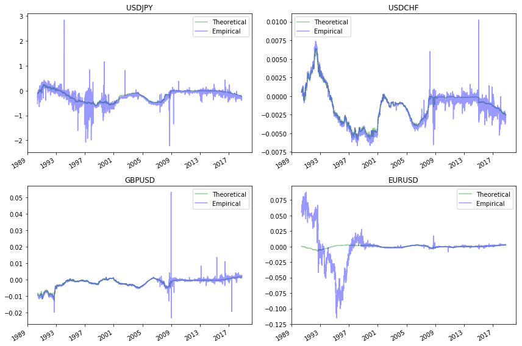

```python
fig, ax = plt.subplots(2, 2, figsize=(12, 8))
ax = ax.ravel()
for i in range(len(curren)):
    swap_points[curren[i]].rename('Theoretical').to_frame().plot(title=curren[i], c='g', alpha=0.4, ax=ax[i])
    difs[curren[i]].rename('Empirical').to_frame().plot(c='b', alpha=0.4, ax=ax[i])
plt.tight_layout()
```

As we can see there are some differences between both swap points computations but most of them are explained as some fluctuations of the empirical price around the computed theoretical swap points, which can be explained by the afore-mentioned causes.

Also note that for USDCHF and GBPUSD most of the deviations take place after 2008, where the empirical swap points start to oscillate around the theoretical price.

However there is a systematic difference in the price of the empirical swap points and the theoretical ones for the EUR, at the beginning of the interval studied.

If we study these differences since the actual inception date of the Euro as a currency in January of 1999, we get a more sensible result:

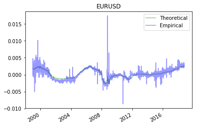

```python
ax = swap_points['EURUSD'].loc['19990101':].rename('Theoretical').to_frame().plot(title='EURUSD', c='g', alpha=0.4)
difs['EURUSD'].loc['19990101':].rename('Empirical').to_frame().plot(c='b', alpha=0.4, ax=ax);
```

Even though there are still some differences, they are much more in line with the other currency pairs.

This fact clearly indicates that the forward, the spot and the interest rates for the Euro probably don't follow a coherent convention of how they are calculated in the dates prior to the EUR inception date in 01/01/1999.

## Filtered comparison:

We can take a centered 40-days moving average (totally arbitrary window, by the way) in order to filter the noise of the empirical swap points and have a more neat visual comparison.

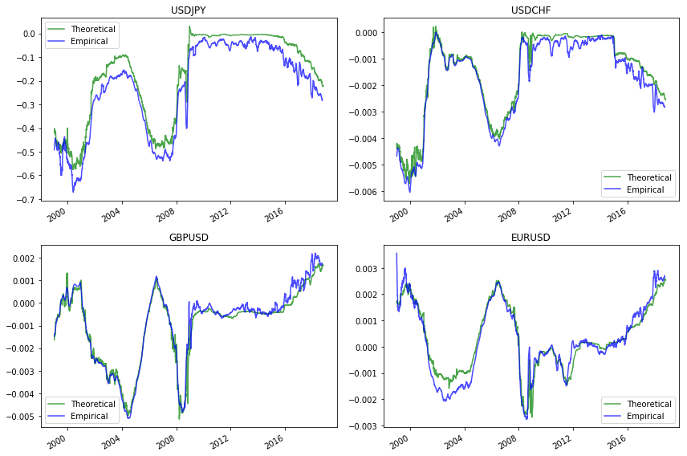

```python
fig, ax = plt.subplots(2, 2, figsize=(12, 8))
ax = ax.ravel()
for i in range(len(curren)):
    swap_points[curren[i]].rename('Theoretical').to_frame().loc['19990101':].plot(title=curren[i], c='g', alpha=0.7, ax=ax[i])
    difs[curren[i]].rolling(40, center=True).mean().rename('Empirical').to_frame().loc['19990101':].plot(c='b', alpha=0.7, ax=ax[i])
plt.tight_layout()
```

Definitely there are some differences but the approximation seems good enough.

### As a conclusion, we propose to use the theoretical forward prices in our analysis (when necessary) in order to have a more idealised measure of the cost of hedging.